# Risk Factor Analysis

## Outcome Variable

**Outcome Variable:** ever_sstunted

## Predictor Variables

**Intervention Variable:** fhtcm

**Adjustment Set:**

- arm
- W_mage
- W_fage
- meducyrs
- feducyrs
- W_mhtcm
- W_mwtkg
- W_mbmi
- single
- delta_W_mage
- delta_W_fage
- delta_meducyrs
- delta_feducyrs
- delta_W_mhtcm
- delta_W_mwtkg
- delta_W_mbmi
- delta_single

## Stratifying Variables

The analysis was stratified on these variable(s):

- agecat
- studyid
- country

## Data Summary

| agecat | studyid | country | fhtcm | ever_sstunted | n_cell | n |
| --- | --- | --- | --- | --- | --- | --- |
| 0-24 months | ki1000304b-SAS-CompFeed | INDIA | >=167 cm | 0 | 307 | 907 |
| 0-24 months | ki1000304b-SAS-CompFeed | INDIA | >=167 cm | 1 | 103 | 907 |
| 0-24 months | ki1000304b-SAS-CompFeed | INDIA | <162 cm | 0 | 130 | 907 |
| 0-24 months | ki1000304b-SAS-CompFeed | INDIA | <162 cm | 1 | 100 | 907 |
| 0-24 months | ki1000304b-SAS-CompFeed | INDIA | [162-167) cm | 0 | 159 | 907 |
| 0-24 months | ki1000304b-SAS-CompFeed | INDIA | [162-167) cm | 1 | 108 | 907 |
| 0-24 months | ki1000304b-SAS-FoodSuppl | INDIA | >=167 cm | 0 | 62 | 399 |
| 0-24 months | ki1000304b-SAS-FoodSuppl | INDIA | >=167 cm | 1 | 44 | 399 |
| 0-24 months | ki1000304b-SAS-FoodSuppl | INDIA | <162 cm | 0 | 69 | 399 |
| 0-24 months | ki1000304b-SAS-FoodSuppl | INDIA | <162 cm | 1 | 94 | 399 |
| 0-24 months | ki1000304b-SAS-FoodSuppl | INDIA | [162-167) cm | 0 | 72 | 399 |
| 0-24 months | ki1000304b-SAS-FoodSuppl | INDIA | [162-167) cm | 1 | 58 | 399 |
| 0-24 months | ki1101329-Keneba | GAMBIA | >=167 cm | 0 | 972 | 1929 |
| 0-24 months | ki1101329-Keneba | GAMBIA | >=167 cm | 1 | 273 | 1929 |
| 0-24 months | ki1101329-Keneba | GAMBIA | <162 cm | 0 | 98 | 1929 |
| 0-24 months | ki1101329-Keneba | GAMBIA | <162 cm | 1 | 34 | 1929 |
| 0-24 months | ki1101329-Keneba | GAMBIA | [162-167) cm | 0 | 413 | 1929 |
| 0-24 months | ki1101329-Keneba | GAMBIA | [162-167) cm | 1 | 139 | 1929 |
| 0-24 months | ki1119695-PROBIT | BELARUS | >=167 cm | 0 | 11328 | 12537 |
| 0-24 months | ki1119695-PROBIT | BELARUS | >=167 cm | 1 | 416 | 12537 |
| 0-24 months | ki1119695-PROBIT | BELARUS | <162 cm | 0 | 147 | 12537 |
| 0-24 months | ki1119695-PROBIT | BELARUS | <162 cm | 1 | 21 | 12537 |
| 0-24 months | ki1119695-PROBIT | BELARUS | [162-167) cm | 0 | 582 | 12537 |
| 0-24 months | ki1119695-PROBIT | BELARUS | [162-167) cm | 1 | 43 | 12537 |
| 0-24 months | ki1135781-COHORTS | GUATEMALA | >=167 cm | 0 | 37 | 496 |
| 0-24 months | ki1135781-COHORTS | GUATEMALA | >=167 cm | 1 | 27 | 496 |
| 0-24 months | ki1135781-COHORTS | GUATEMALA | <162 cm | 0 | 103 | 496 |
| 0-24 months | ki1135781-COHORTS | GUATEMALA | <162 cm | 1 | 190 | 496 |
| 0-24 months | ki1135781-COHORTS | GUATEMALA | [162-167) cm | 0 | 77 | 496 |
| 0-24 months | ki1135781-COHORTS | GUATEMALA | [162-167) cm | 1 | 62 | 496 |
| 0-6 months | ki1000304b-SAS-CompFeed | INDIA | >=167 cm | 0 | 372 | 905 |
| 0-6 months | ki1000304b-SAS-CompFeed | INDIA | >=167 cm | 1 | 38 | 905 |
| 0-6 months | ki1000304b-SAS-CompFeed | INDIA | <162 cm | 0 | 178 | 905 |
| 0-6 months | ki1000304b-SAS-CompFeed | INDIA | <162 cm | 1 | 51 | 905 |
| 0-6 months | ki1000304b-SAS-CompFeed | INDIA | [162-167) cm | 0 | 222 | 905 |
| 0-6 months | ki1000304b-SAS-CompFeed | INDIA | [162-167) cm | 1 | 44 | 905 |
| 0-6 months | ki1000304b-SAS-FoodSuppl | INDIA | >=167 cm | 0 | 99 | 397 |
| 0-6 months | ki1000304b-SAS-FoodSuppl | INDIA | >=167 cm | 1 | 7 | 397 |
| 0-6 months | ki1000304b-SAS-FoodSuppl | INDIA | <162 cm | 0 | 138 | 397 |
| 0-6 months | ki1000304b-SAS-FoodSuppl | INDIA | <162 cm | 1 | 24 | 397 |
| 0-6 months | ki1000304b-SAS-FoodSuppl | INDIA | [162-167) cm | 0 | 114 | 397 |
| 0-6 months | ki1000304b-SAS-FoodSuppl | INDIA | [162-167) cm | 1 | 15 | 397 |
| 0-6 months | ki1101329-Keneba | GAMBIA | >=167 cm | 0 | 987 | 1723 |
| 0-6 months | ki1101329-Keneba | GAMBIA | >=167 cm | 1 | 126 | 1723 |
| 0-6 months | ki1101329-Keneba | GAMBIA | <162 cm | 0 | 116 | 1723 |
| 0-6 months | ki1101329-Keneba | GAMBIA | <162 cm | 1 | 8 | 1723 |
| 0-6 months | ki1101329-Keneba | GAMBIA | [162-167) cm | 0 | 431 | 1723 |
| 0-6 months | ki1101329-Keneba | GAMBIA | [162-167) cm | 1 | 55 | 1723 |
| 0-6 months | ki1119695-PROBIT | BELARUS | >=167 cm | 0 | 11610 | 12537 |
| 0-6 months | ki1119695-PROBIT | BELARUS | >=167 cm | 1 | 134 | 12537 |
| 0-6 months | ki1119695-PROBIT | BELARUS | <162 cm | 0 | 162 | 12537 |
| 0-6 months | ki1119695-PROBIT | BELARUS | <162 cm | 1 | 6 | 12537 |
| 0-6 months | ki1119695-PROBIT | BELARUS | [162-167) cm | 0 | 605 | 12537 |
| 0-6 months | ki1119695-PROBIT | BELARUS | [162-167) cm | 1 | 20 | 12537 |
| 0-6 months | ki1135781-COHORTS | GUATEMALA | >=167 cm | 0 | 44 | 337 |
| 0-6 months | ki1135781-COHORTS | GUATEMALA | >=167 cm | 1 | 5 | 337 |
| 0-6 months | ki1135781-COHORTS | GUATEMALA | <162 cm | 0 | 166 | 337 |
| 0-6 months | ki1135781-COHORTS | GUATEMALA | <162 cm | 1 | 30 | 337 |
| 0-6 months | ki1135781-COHORTS | GUATEMALA | [162-167) cm | 0 | 86 | 337 |
| 0-6 months | ki1135781-COHORTS | GUATEMALA | [162-167) cm | 1 | 6 | 337 |

The following strata were considered:

- agecat: 0-24 months, studyid: ki1000304b-SAS-CompFeed, country: INDIA
- agecat: 0-24 months, studyid: ki1000304b-SAS-FoodSuppl, country: INDIA
- agecat: 0-24 months, studyid: ki1101329-Keneba, country: GAMBIA
- agecat: 0-24 months, studyid: ki1119695-PROBIT, country: BELARUS
- agecat: 0-24 months, studyid: ki1135781-COHORTS, country: GUATEMALA
- agecat: 0-6 months, studyid: ki1000304b-SAS-CompFeed, country: INDIA
- agecat: 0-6 months, studyid: ki1000304b-SAS-FoodSuppl, country: INDIA
- agecat: 0-6 months, studyid: ki1101329-Keneba, country: GAMBIA
- agecat: 0-6 months, studyid: ki1119695-PROBIT, country: BELARUS
- agecat: 0-6 months, studyid: ki1135781-COHORTS, country: GUATEMALA

## Methods Detail

We’re interested in the causal parameters $E[Y_a]$ for all values of $a \in \mathcal{A}$. These parameters represent the mean outcome if, possibly contrary to fact, we intervened to set all units to have $A=a$. Under the randomization and positivity assumptions, these are identified by the statistical parameters $\psi_a=E_W[E_{Y|A,W}(Y|A=a,W)]$. In addition, we’re interested in the mean of $Y$, $E[Y]$ under no intervention (the observed mean). We will estimate these parameters by using SuperLearner to fit the relevant likelihood factors – $E_{Y|A,W}(Y|A=a,W)$ and $p(A=a|W)$, and then updating our likelihood fit using a joint TMLE.

For unadjusted analyses ($W=\{\}$), initial likelihoods were estimated using Lrnr_glm to estimate the simple $E(Y|A)$ and Lrnr_mean to estimate $p(A)$. For adjusted analyses, a small library containing Lrnr_glmnet, Lrnr_xgboost, and Lrnr_mean was used.

Having estimated these parameters, we will then use the delta method to estimate relative risks and attributable risks relative to a prespecified baseline level of $A$.

# Results Detail

## Results Plots

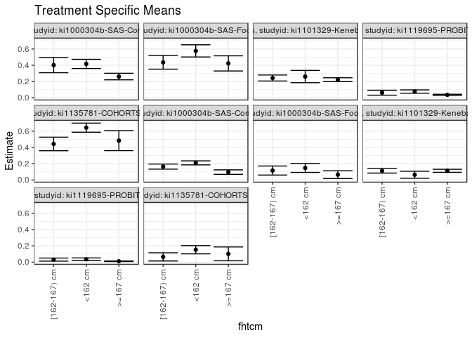

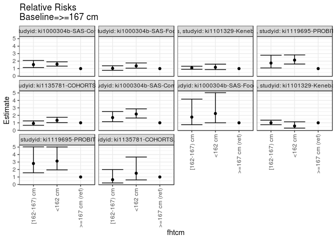

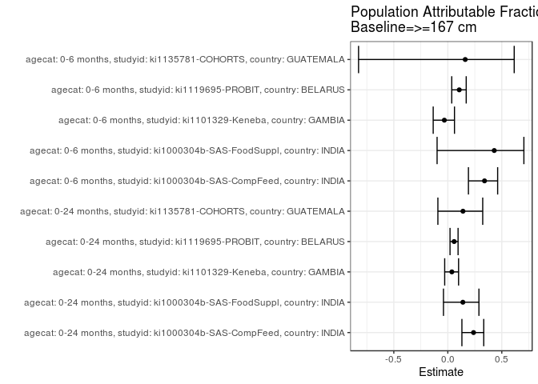

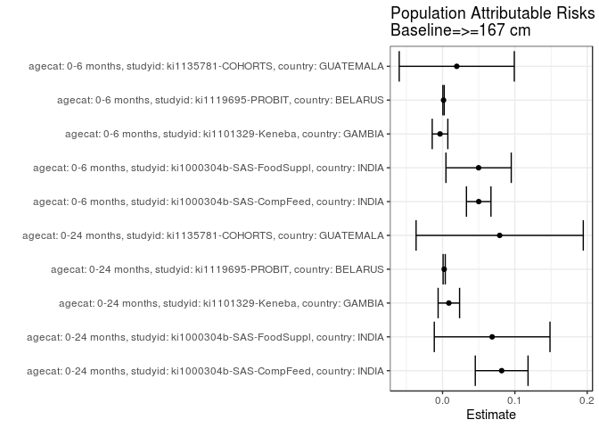

## Results Table

### Parameter: TSM

| agecat | studyid | country | intervention_level | baseline_level | estimate | ci_lower | ci_upper |
| --- | --- | --- | --- | --- | --- | --- | --- |
| 0-24 months | ki1000304b-SAS-CompFeed | INDIA | >=167 cm | NA | 0.2611710 | 0.2208196 | 0.3015223 |
| 0-24 months | ki1000304b-SAS-CompFeed | INDIA | <162 cm | NA | 0.4158747 | 0.3594110 | 0.4723384 |
| 0-24 months | ki1000304b-SAS-CompFeed | INDIA | [162-167) cm | NA | 0.4016992 | 0.3081781 | 0.4952202 |
| 0-24 months | ki1000304b-SAS-FoodSuppl | INDIA | >=167 cm | NA | 0.4226745 | 0.3295753 | 0.5157737 |
| 0-24 months | ki1000304b-SAS-FoodSuppl | INDIA | <162 cm | NA | 0.5762193 | 0.5013273 | 0.6511114 |
| 0-24 months | ki1000304b-SAS-FoodSuppl | INDIA | [162-167) cm | NA | 0.4354895 | 0.3518495 | 0.5191295 |
| 0-24 months | ki1101329-Keneba | GAMBIA | >=167 cm | NA | 0.2225195 | 0.1988038 | 0.2462351 |
| 0-24 months | ki1101329-Keneba | GAMBIA | <162 cm | NA | 0.2610309 | 0.1858704 | 0.3361914 |
| 0-24 months | ki1101329-Keneba | GAMBIA | [162-167) cm | NA | 0.2435121 | 0.2067613 | 0.2802629 |
| 0-24 months | ki1119695-PROBIT | BELARUS | >=167 cm | NA | 0.0360440 | 0.0283550 | 0.0437331 |
| 0-24 months | ki1119695-PROBIT | BELARUS | <162 cm | NA | 0.0769872 | 0.0565266 | 0.0974478 |
| 0-24 months | ki1119695-PROBIT | BELARUS | [162-167) cm | NA | 0.0627699 | 0.0324094 | 0.0931305 |
| 0-24 months | ki1135781-COHORTS | GUATEMALA | >=167 cm | NA | 0.4835142 | 0.3604950 | 0.6065333 |
| 0-24 months | ki1135781-COHORTS | GUATEMALA | <162 cm | NA | 0.6425212 | 0.5866168 | 0.6984257 |
| 0-24 months | ki1135781-COHORTS | GUATEMALA | [162-167) cm | NA | 0.4426061 | 0.3594374 | 0.5257747 |
| 0-6 months | ki1000304b-SAS-CompFeed | INDIA | >=167 cm | NA | 0.0969903 | 0.0693500 | 0.1246307 |
| 0-6 months | ki1000304b-SAS-CompFeed | INDIA | <162 cm | NA | 0.2103435 | 0.1858404 | 0.2348466 |
| 0-6 months | ki1000304b-SAS-CompFeed | INDIA | [162-167) cm | NA | 0.1644033 | 0.1332990 | 0.1955075 |
| 0-6 months | ki1000304b-SAS-FoodSuppl | INDIA | >=167 cm | NA | 0.0660377 | 0.0187004 | 0.1133750 |
| 0-6 months | ki1000304b-SAS-FoodSuppl | INDIA | <162 cm | NA | 0.1481481 | 0.0933749 | 0.2029214 |
| 0-6 months | ki1000304b-SAS-FoodSuppl | INDIA | [162-167) cm | NA | 0.1162791 | 0.0608919 | 0.1716662 |
| 0-6 months | ki1101329-Keneba | GAMBIA | >=167 cm | NA | 0.1132075 | 0.0945877 | 0.1318274 |
| 0-6 months | ki1101329-Keneba | GAMBIA | <162 cm | NA | 0.0645161 | 0.0212632 | 0.1077691 |
| 0-6 months | ki1101329-Keneba | GAMBIA | [162-167) cm | NA | 0.1131687 | 0.0849953 | 0.1413422 |
| 0-6 months | ki1119695-PROBIT | BELARUS | >=167 cm | NA | 0.0114101 | 0.0084273 | 0.0143929 |
| 0-6 months | ki1119695-PROBIT | BELARUS | <162 cm | NA | 0.0357143 | 0.0189767 | 0.0524519 |
| 0-6 months | ki1119695-PROBIT | BELARUS | [162-167) cm | NA | 0.0320000 | 0.0134389 | 0.0505611 |
| 0-6 months | ki1135781-COHORTS | GUATEMALA | >=167 cm | NA | 0.1020408 | 0.0171598 | 0.1869218 |
| 0-6 months | ki1135781-COHORTS | GUATEMALA | <162 cm | NA | 0.1530612 | 0.1025807 | 0.2035418 |
| 0-6 months | ki1135781-COHORTS | GUATEMALA | [162-167) cm | NA | 0.0652174 | 0.0146889 | 0.1157459 |

### Parameter: E(Y)

| agecat | studyid | country | intervention_level | baseline_level | estimate | ci_lower | ci_upper |
| --- | --- | --- | --- | --- | --- | --- | --- |
| 0-24 months | ki1000304b-SAS-CompFeed | INDIA | NA | NA | 0.3428886 | 0.3091585 | 0.3766188 |
| 0-24 months | ki1000304b-SAS-FoodSuppl | INDIA | NA | NA | 0.4912281 | 0.4421136 | 0.5403426 |
| 0-24 months | ki1101329-Keneba | GAMBIA | NA | NA | 0.2312079 | 0.2123887 | 0.2500270 |
| 0-24 months | ki1119695-PROBIT | BELARUS | NA | NA | 0.0382867 | 0.0302846 | 0.0462887 |
| 0-24 months | ki1135781-COHORTS | GUATEMALA | NA | NA | 0.5625000 | 0.5187986 | 0.6062014 |
| 0-6 months | ki1000304b-SAS-CompFeed | INDIA | NA | NA | 0.1469613 | 0.1306617 | 0.1632610 |
| 0-6 months | ki1000304b-SAS-FoodSuppl | INDIA | NA | NA | 0.1158690 | 0.0843449 | 0.1473931 |
| 0-6 months | ki1101329-Keneba | GAMBIA | NA | NA | 0.1096924 | 0.0949323 | 0.1244525 |
| 0-6 months | ki1119695-PROBIT | BELARUS | NA | NA | 0.0127622 | 0.0094933 | 0.0160311 |
| 0-6 months | ki1135781-COHORTS | GUATEMALA | NA | NA | 0.1216617 | 0.0867086 | 0.1566149 |

### Parameter: RR

| agecat | studyid | country | intervention_level | baseline_level | estimate | ci_lower | ci_upper |
| --- | --- | --- | --- | --- | --- | --- | --- |
| 0-24 months | ki1000304b-SAS-CompFeed | INDIA | >=167 cm | >=167 cm | 1.0000000 | 1.0000000 | 1.000000 |
| 0-24 months | ki1000304b-SAS-CompFeed | INDIA | <162 cm | >=167 cm | 1.5923465 | 1.3293107 | 1.907430 |
| 0-24 months | ki1000304b-SAS-CompFeed | INDIA | [162-167) cm | >=167 cm | 1.5380698 | 1.1343543 | 2.085467 |
| 0-24 months | ki1000304b-SAS-FoodSuppl | INDIA | >=167 cm | >=167 cm | 1.0000000 | 1.0000000 | 1.000000 |
| 0-24 months | ki1000304b-SAS-FoodSuppl | INDIA | <162 cm | >=167 cm | 1.3632697 | 1.0575299 | 1.757401 |
| 0-24 months | ki1000304b-SAS-FoodSuppl | INDIA | [162-167) cm | >=167 cm | 1.0303189 | 0.7710589 | 1.376752 |
| 0-24 months | ki1101329-Keneba | GAMBIA | >=167 cm | >=167 cm | 1.0000000 | 1.0000000 | 1.000000 |
| 0-24 months | ki1101329-Keneba | GAMBIA | <162 cm | >=167 cm | 1.1730697 | 0.8635500 | 1.593530 |
| 0-24 months | ki1101329-Keneba | GAMBIA | [162-167) cm | >=167 cm | 1.0943405 | 0.9103622 | 1.315500 |
| 0-24 months | ki1119695-PROBIT | BELARUS | >=167 cm | >=167 cm | 1.0000000 | 1.0000000 | 1.000000 |
| 0-24 months | ki1119695-PROBIT | BELARUS | <162 cm | >=167 cm | 2.1359201 | 1.6109281 | 2.832004 |
| 0-24 months | ki1119695-PROBIT | BELARUS | [162-167) cm | >=167 cm | 1.7414783 | 1.0869275 | 2.790201 |
| 0-24 months | ki1135781-COHORTS | GUATEMALA | >=167 cm | >=167 cm | 1.0000000 | 1.0000000 | 1.000000 |
| 0-24 months | ki1135781-COHORTS | GUATEMALA | <162 cm | >=167 cm | 1.3288571 | 1.0168666 | 1.736571 |
| 0-24 months | ki1135781-COHORTS | GUATEMALA | [162-167) cm | >=167 cm | 0.9153942 | 0.6683550 | 1.253745 |
| 0-6 months | ki1000304b-SAS-CompFeed | INDIA | >=167 cm | >=167 cm | 1.0000000 | 1.0000000 | 1.000000 |
| 0-6 months | ki1000304b-SAS-CompFeed | INDIA | <162 cm | >=167 cm | 2.1687061 | 1.6408678 | 2.866341 |
| 0-6 months | ki1000304b-SAS-CompFeed | INDIA | [162-167) cm | >=167 cm | 1.6950481 | 1.1472405 | 2.504434 |
| 0-6 months | ki1000304b-SAS-FoodSuppl | INDIA | >=167 cm | >=167 cm | 1.0000000 | 1.0000000 | 1.000000 |
| 0-6 months | ki1000304b-SAS-FoodSuppl | INDIA | <162 cm | >=167 cm | 2.2433862 | 1.0014353 | 5.025568 |
| 0-6 months | ki1000304b-SAS-FoodSuppl | INDIA | [162-167) cm | >=167 cm | 1.7607973 | 0.7446161 | 4.163766 |
| 0-6 months | ki1101329-Keneba | GAMBIA | >=167 cm | >=167 cm | 1.0000000 | 1.0000000 | 1.000000 |
| 0-6 months | ki1101329-Keneba | GAMBIA | <162 cm | >=167 cm | 0.5698925 | 0.2857583 | 1.136546 |
| 0-6 months | ki1101329-Keneba | GAMBIA | [162-167) cm | >=167 cm | 0.9996571 | 0.7417675 | 1.347207 |
| 0-6 months | ki1119695-PROBIT | BELARUS | >=167 cm | >=167 cm | 1.0000000 | 1.0000000 | 1.000000 |
| 0-6 months | ki1119695-PROBIT | BELARUS | <162 cm | >=167 cm | 3.1300640 | 1.9528656 | 5.016884 |
| 0-6 months | ki1119695-PROBIT | BELARUS | [162-167) cm | >=167 cm | 2.8045373 | 1.5627071 | 5.033208 |
| 0-6 months | ki1135781-COHORTS | GUATEMALA | >=167 cm | >=167 cm | 1.0000000 | 1.0000000 | 1.000000 |
| 0-6 months | ki1135781-COHORTS | GUATEMALA | <162 cm | >=167 cm | 1.5000000 | 0.6130158 | 3.670378 |
| 0-6 months | ki1135781-COHORTS | GUATEMALA | [162-167) cm | >=167 cm | 0.6391304 | 0.2050700 | 1.991943 |

### Parameter: PAR

| agecat | studyid | country | intervention_level | baseline_level | estimate | ci_lower | ci_upper |
| --- | --- | --- | --- | --- | --- | --- | --- |
| 0-24 months | ki1000304b-SAS-CompFeed | INDIA | >=167 cm | NA | 0.0817177 | 0.0452427 | 0.1181927 |
| 0-24 months | ki1000304b-SAS-FoodSuppl | INDIA | >=167 cm | NA | 0.0685536 | -0.0114468 | 0.1485540 |
| 0-24 months | ki1101329-Keneba | GAMBIA | >=167 cm | NA | 0.0086884 | -0.0061574 | 0.0235342 |
| 0-24 months | ki1119695-PROBIT | BELARUS | >=167 cm | NA | 0.0022426 | 0.0007483 | 0.0037369 |
| 0-24 months | ki1135781-COHORTS | GUATEMALA | >=167 cm | NA | 0.0789858 | -0.0366042 | 0.1945759 |
| 0-6 months | ki1000304b-SAS-CompFeed | INDIA | >=167 cm | NA | 0.0499710 | 0.0330248 | 0.0669172 |
| 0-6 months | ki1000304b-SAS-FoodSuppl | INDIA | >=167 cm | NA | 0.0498313 | 0.0046873 | 0.0949753 |
| 0-6 months | ki1101329-Keneba | GAMBIA | >=167 cm | NA | -0.0035152 | -0.0143156 | 0.0072853 |
| 0-6 months | ki1119695-PROBIT | BELARUS | >=167 cm | NA | 0.0013521 | 0.0004071 | 0.0022971 |
| 0-6 months | ki1135781-COHORTS | GUATEMALA | >=167 cm | NA | 0.0196209 | -0.0599489 | 0.0991907 |

### Parameter: PAF

| agecat | studyid | country | intervention_level | baseline_level | estimate | ci_lower | ci_upper |
| --- | --- | --- | --- | --- | --- | --- | --- |
| 0-24 months | ki1000304b-SAS-CompFeed | INDIA | >=167 cm | NA | 0.2383214 | 0.1305346 | 0.3327459 |
| 0-24 months | ki1000304b-SAS-FoodSuppl | INDIA | >=167 cm | NA | 0.1395555 | -0.0401461 | 0.2882109 |
| 0-24 months | ki1101329-Keneba | GAMBIA | >=167 cm | NA | 0.0375783 | -0.0288287 | 0.0996990 |
| 0-24 months | ki1119695-PROBIT | BELARUS | >=167 cm | NA | 0.0585745 | 0.0205766 | 0.0950982 |
| 0-24 months | ki1135781-COHORTS | GUATEMALA | >=167 cm | NA | 0.1404192 | -0.0918968 | 0.3233069 |
| 0-6 months | ki1000304b-SAS-CompFeed | INDIA | >=167 cm | NA | 0.3400283 | 0.1910582 | 0.4615649 |
| 0-6 months | ki1000304b-SAS-FoodSuppl | INDIA | >=167 cm | NA | 0.4300656 | -0.0992516 | 0.7045033 |
| 0-6 months | ki1101329-Keneba | GAMBIA | >=167 cm | NA | -0.0320455 | -0.1352786 | 0.0618004 |
| 0-6 months | ki1119695-PROBIT | BELARUS | >=167 cm | NA | 0.1059488 | 0.0364883 | 0.1704018 |
| 0-6 months | ki1135781-COHORTS | GUATEMALA | >=167 cm | NA | 0.1612743 | -0.8265131 | 0.6148613 |